# QLS ODE Assignment - Preethi Ravikumar

Exercise-1

Compute and plot the population size over the first 50 generations for r = 0.5, 2.8, 3.3.

```r
library(deSolve)
#x0 is the initial value of the population. xn is the measure of population growth in nth generation. r is the growth rate.
x0 <- rep(0.1,3)
r <- c(0.5,2.8,3.3) # growth rate
xi <- matrix(data=NA,nrow=50,ncol=3) #defining xn
xi[1,] <- x0
xn <- x0
for(i in 2:50){
xi[i,] <- xn*(1-xn)*r
xn <- xi[i,]
}
```

What did you notice with different values of r? Can you give a heuristic explanation for the behaviour you observe?

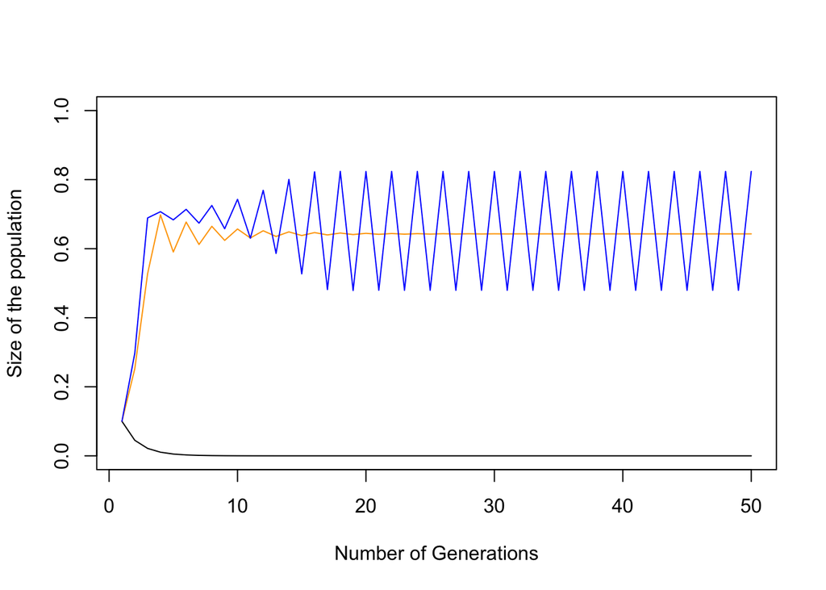

```r
{plot(xi[,1],
     type = "l",
     col = "black",
     ylim =c(0,1),
     xlab = "Number of Generations",
     ylab = "Size of the population")
  lines(xi[,2],col="orange")
  lines(xi[,3],col="blue")}
```

Exercise-2

Implement the Forward Euler algorithm and compute the solution to the following initial value problem for t ∈ [0, 5], for the following step sizes: h = 0.1, 0.01, 0.001.

```r
euler <- function(f, x0, tmax, h) {
    t0 <- 0
    x<-array(NA, dim = c(tmax/h+1,2))
    t <- seq(0,tmax,h)
    x[,1]<-t
    x[1,2]<-x0
    for(i in 2:((tmax/h)+1)) {
      x[i,2]<-x[i-1,2]+h*x[i-1,2]
       }

    return(data.frame(x = x, t = t))
}
e1 = euler(f=function(x){return(x)},x0 = 1,tmax = 5,h=0.1)
e2 = e = euler(f=function(x){return(x)},x0 = 1,tmax = 5,h=0.01)
e3 = e = euler(f=function(x){return(x)},x0 = 1,tmax = 5,h=0.001)
```

Plot these solution overlaid with the function x(t) = exp(t). What do you observe? Is this what you would expect?Why or why not?

In the plot below, as we would expect, we can see that dx/dt tends towards e^x as h goes to zero.

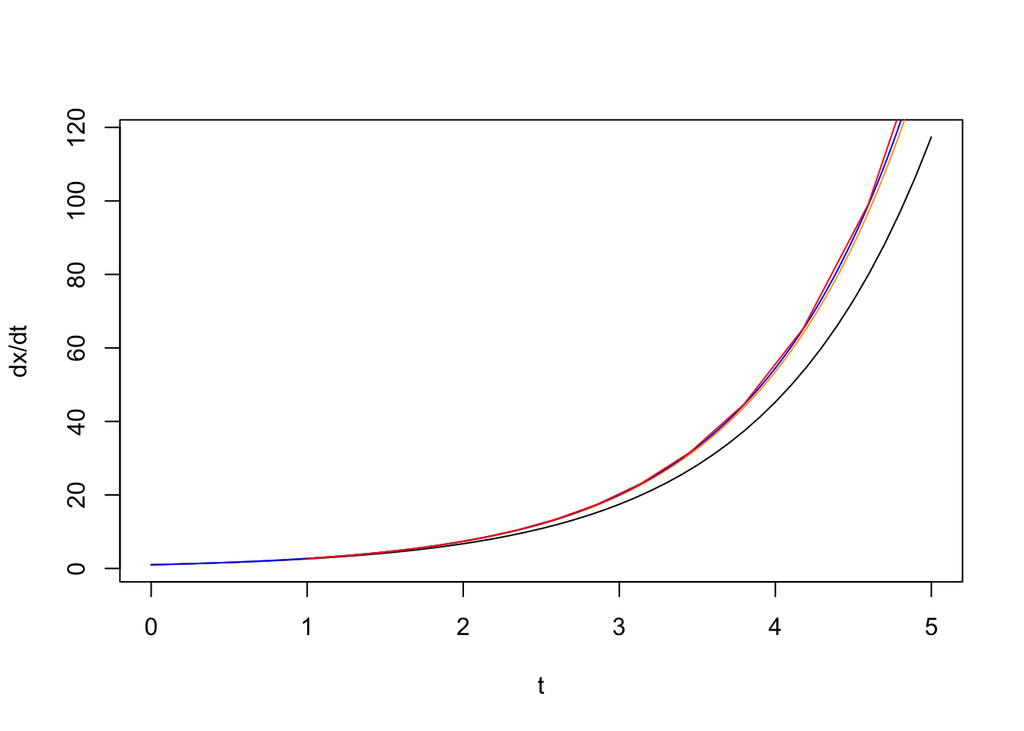

```r
{plot(e1$t,e1$x.2,type = "l", col = "black",xlab = "t", ylab = "dx/dt")
lines(e2$t,e2$x.2, type = "l", col = "orange")
lines(e3$t,e3$x.2,type = "l", col = "blue")
lines(e1$x.2,exp(e1$x.2),type="l",col= "red")}
```

Exercise -3 FitzHugh Nagumo Model

Part-1 Compute the solution to this system until t = 400 for v(0) = 1, w(0) = 0.1, I = 0.5 (a step size of 0.01 should suffice).

```r
I <- 0.5
a <- 0.7
b <- 0.8
e <- 0.08
tmax <- 400
h <- 0.01
t <- seq(0,tmax,h)
out <- array(NA, dim = c(tmax/h+1, 3))
out[,1] <- t
out[1,2] <- 1
out[1,3] <- 0.1
for(i in 2:((tmax/h)+1)) {
     out[i,2] <- out[i-1,2]+h*(out[i-1,2]-((out[i-1,2]^3)/3)-out[i-1,3]+I)
     out[i,3] <- out[i-1,3]+h*(e*(out[i-1,2]+a-b*out[i-1,3]))
}
```

Plot the variable v against t – you should see oscillations.

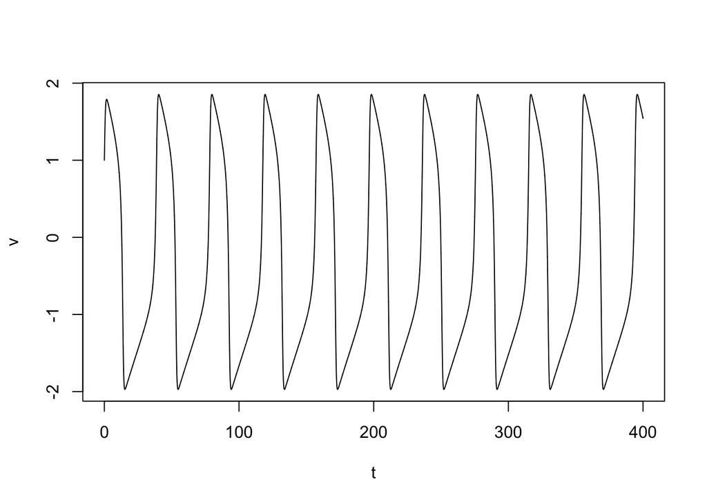

```r
plot(x = out[,1], y = out[,2], type = "l", xlab = "t", ylab = "v")
```

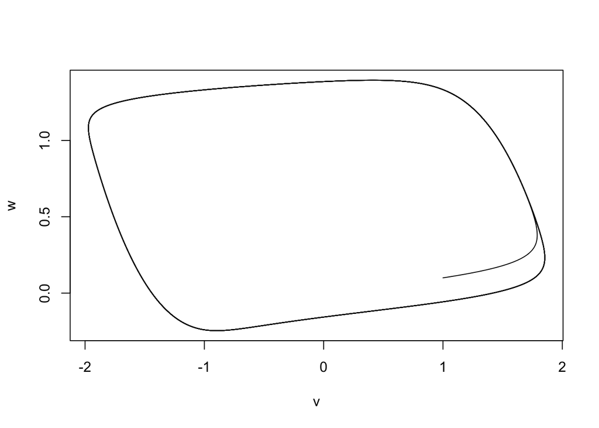

```r
plot(x = out[,2], y = out[,3], type = "l", xlab = "v", ylab = "w")
```

```r
#FHN(tmax = 400,a = 0.7, b =0.8,e=0.08, I=0.5,h=0.01)
```

Exercise-3(Part-2)

Plot v against w, that is, look at the trajectory in phase space. Notice that after a small transient, the trajectory stays on a loop in phase space. This is a special type of attractor called a limit cycle. Calculate the v-nullcline and w-nullcline and graph these on the same plot as your trajectory.

```r
library(phaseR)
```

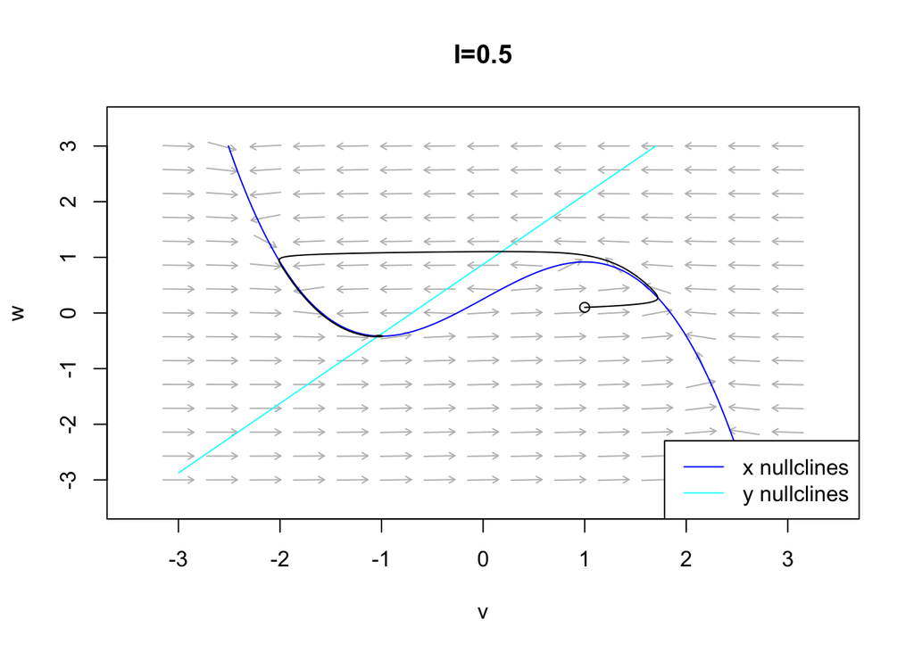

```r
FHN <- function(t, y, parameters) {
  I_0 <- parameters
  e<- 0.08
  b<-0.8
  a<-0.7
  dy <- numeric(2)
  dy[1] <- 2 *  ( y[1] - 1/3 * y[1]^3 - y[2]) + I_0
  dy[2] <- e*(y[1] + a - b*(y[2]))
  return(list(dy))
}
phasePlot <- function(FHN, I_0=0.5){
  FHN.flowField  <- flowField(FHN, xlim = c(-3, 3),
                              ylim = c(-3, 3),
                              xlab="v", ylab="w",
                              main=paste0("I=", I_0),
                              parameters = I_0,
                              points = 15, add = FALSE)
  FHN.nullclines <- nullclines(FHN, xlim = c(-3, 3),
                               ylim = c(-3, 3),
                               parameters = I_0,
                               points = 400)
  y0 <- c(1, 0.1)
  FHN.trajectory <- trajectory(FHN, y0 = y0, tlim = c(0,400),
                               parameters = I_0)
}

phasePlot(FHN, I_0 = 0.5)
```

Exercise-3(part-3) Calculate the fixed-point of the system.

```r
v <- polyroot(z =c((b*I-a), (b-1), 0,-b/3))[2]
w <- (v+a)/b
c(v,w)
```

```
## [1] -0.8048477+0i -0.1310597+0i
```

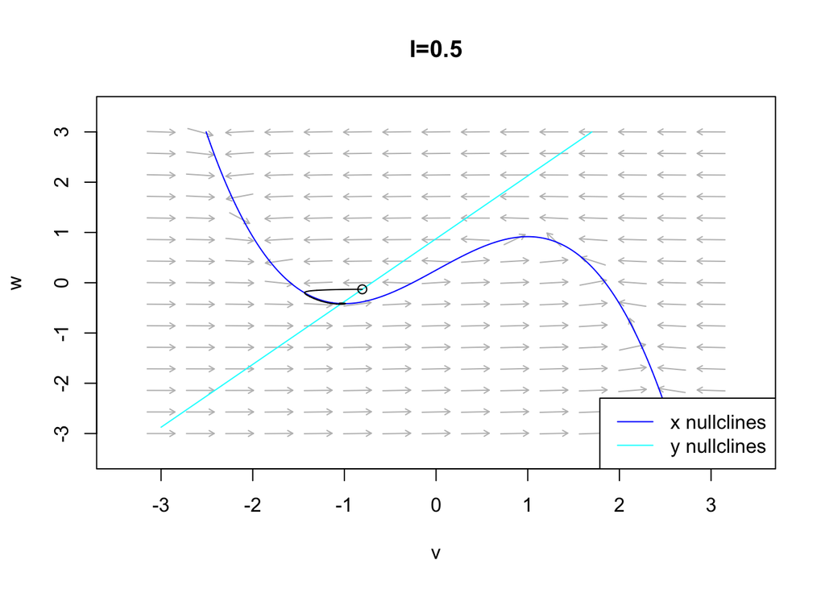

```r
phasePlot <- function(FHN, I_0=0.5){
  FHN.flowField  <- flowField(FHN, xlim = c(-3, 3),
                              ylim = c(-3, 3),
                              xlab="v", ylab="w",
                              main=paste0("I=", I_0),
                              parameters = I_0,
                              points = 15, add = FALSE)
  FHN.nullclines <- nullclines(FHN, xlim = c(-3, 3),
                               ylim = c(-3, 3),
                               parameters = I_0,
                               points = 400)
  y0 <- c(-0.8048477, -0.1310597)
  FHN.trajectory <- trajectory(FHN, y0 = y0, tlim = c(0,400),
                               parameters = I_0)
}

phasePlot(FHN, I_0 = 0.5)
```

Exercise-3(Part-4) Calculate the Jacobian Matrix of the system. Evaluate it at the fixed-point from 3. Now compute the eigenvalues of this matrix.

```r
eigen(x =matrix(data =c(1-v^2, e, -1,-e*b), nrow = 2, ncol = 2))
```

```
## eigen() decomposition
## $values
## [1] 0.1441101+0.1915469i 0.1441101-0.1915469i
##
## $vectors
##                      [,1]                 [,2]
## [1,] 0.9622504+0.0000000i 0.9622504+0.0000000i
## [2,] 0.2002540-0.1843161i 0.2002540+0.1843161i
```

Exercise-3(Part-5) Repeat the above steps with I = 0.

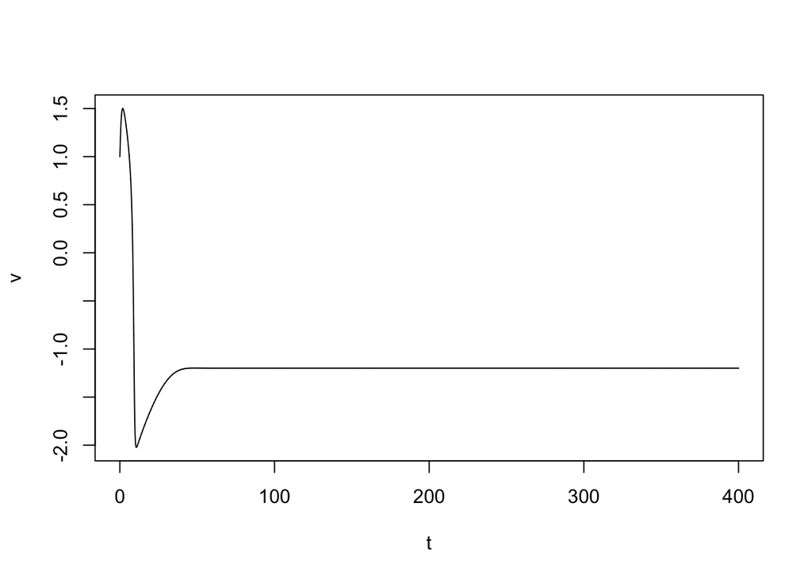

```r
#I=0
I <- 0
a <- 0.7
b <- 0.8
e <- 0.08
tmax <- 400
h <- 0.01
t <- seq(0,tmax,h)
out <- array(NA, dim = c(tmax/h+1, 3))
out[,1] <- t
out[1,2] <- 1
out[1,3] <- 0.1
for(i in 2:((tmax/h)+1)) {
     out[i,2] <- out[i-1,2]+h*(out[i-1,2]-((out[i-1,2]^3)/3)-out[i-1,3]+I)
     out[i,3] <- out[i-1,3]+h*(e*(out[i-1,2]+a-b*out[i-1,3]))
}

plot(x = out[,1], y = out[,2], type = "l", xlab = "t", ylab = "v")
```

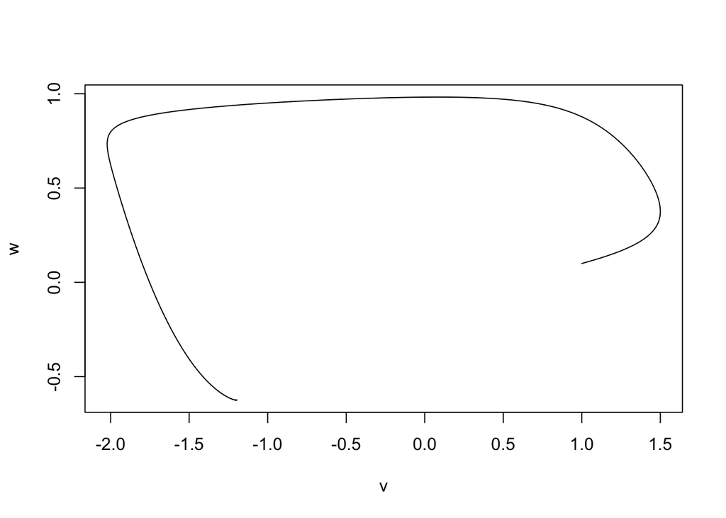

```r
plot(x = out[,2], y = out[,3], type = "l", xlab = "v", ylab = "w")
```

```r
v <-polyroot(z =c((b*I-a), (b-1), 0,-b/3))[2]
w <- (v+a)/b
c(v,w)
```

```
## [1] -1.199408+0i -0.624260+0i
```

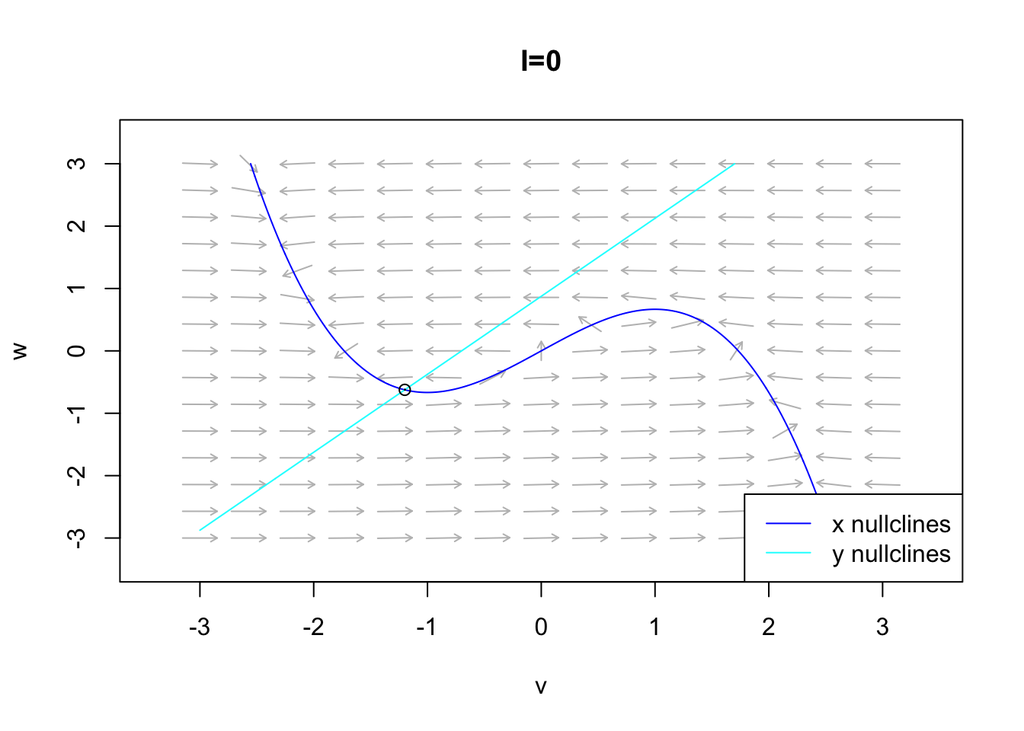

```r
phasePlot <- function(FHN, I_0=0){
  FHN.flowField  <- flowField(FHN, xlim = c(-3, 3),
                              ylim = c(-3, 3),
                              xlab="v", ylab="w",
                              main=paste0("I=", I_0),
                              parameters = I_0,
                              points = 15, add = FALSE)
  FHN.nullclines <- nullclines(FHN, xlim = c(-3, 3),
                               ylim = c(-3, 3),
                               parameters = I_0,
                               points = 400)
  y0 <- c(-1.199408, -0.624260)
  FHN.trajectory <- trajectory(FHN, y0 = y0, tlim = c(0,400),
                               parameters = I_0)
}

phasePlot(FHN, I_0 = 0)
```

```r
eigen(x =matrix(data =c(1-v^2, e, -1,-e*b), nrow = 2, ncol = 2))
```

```
## eigen() decomposition
## $values
## [1] -0.2512898+0.2119493i -0.2512898-0.2119493i
##
## $vectors
##                       [,1]                  [,2]
## [1,]  0.9622504+0.0000000i  0.9622504+0.0000000i
## [2,] -0.1802197-0.2039484i -0.1802197+0.2039484i
```

Exercise-3(part-6) Write a for loop to calculate the steady-state values (v∗,w∗) and its stability for values of I ranging between 0 and 0.5.

```r
tmax = 400
h = 0.01
a = 0.7
b = 0.8
e = 0.08
X <-array(data = NA, dim =c(51,5))
I <-seq(0,0.5,0.01)
for(j in seq(1,51)){
  X[j,1] <- I[j]
  X[j,2] <-polyroot(z =c((b*I[j]-a), (b-1), 0,-b/3))[2]
  X[j,3] <- (X[j,2]+a)/b
  X[j,4:5] <-eigen(x =matrix(data =c(1-X[j,2]^2, e, -1,-e*b), nrow = 2, ncol = 2))$values
}
```

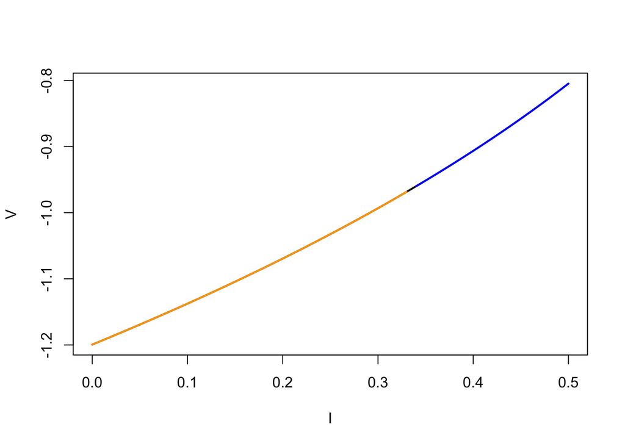

```r
{plot(x = I, y = X[,2], type = "l", col = "black", xlab = "I", ylab = "V", lwd = 2)
lines(x = I[which(Re(X[,4])>0)], y = X[which(Re(X[,4])>0),2], col = "blue", lwd = 2)
lines(x = I[which(Re(X[,4])<0)], y = X[which(Re(X[,4])<0),2], col = "orange", lwd = 2)}
```